# A Bayeisan Network Classifier for Acute Myocardial Infarction Microarray

## 3.4 Model assessment

We tested the following parameters for each models - - Predictive performance: ROC, AUC, PRC - Stability: convergence of features - Interpretability: Pathway enrichment levels of selected features.

### 3.4.1 Predictive performance

Tabu bootstrap gives fair performance (AUC = 0.824 for 10 fold cross validation). The introduction of TAN can moderately enhance its performance (AUC = 0.852). However the introduction of pathway knowledge might have confused the model - AUC has deceased to 0.78 while standard deviation has become significantly larger. This result suggests that inclusion of exogenous knowledge may deteriorate prediction performance - the formulation of **whitelist** is not well-supported by structure learning result, which seems deviate structure learning toward an expert system.

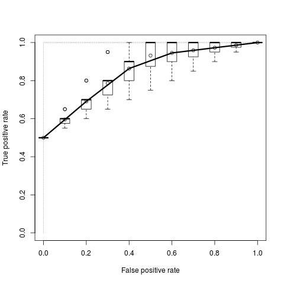

Figure.6 BN built by tabu bootstrap and model averaging

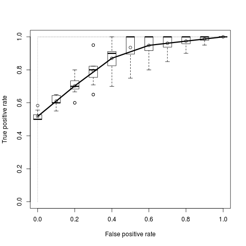

Figure.7 BN built by tabu-TAN

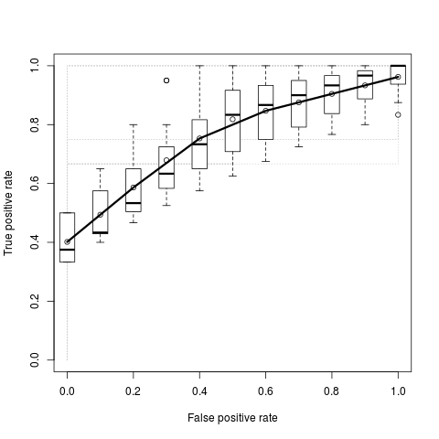

Figure.8 BN built by pathway-TAN

### 3.4.2 Stability

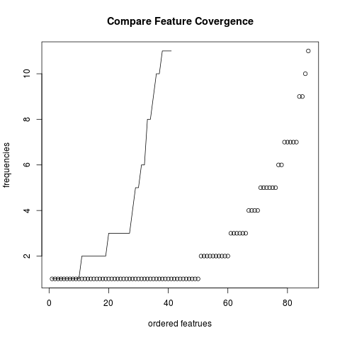

Figure.9 Feature Convergence byt two feature selection methods

### 3.4.3 Bio-intrepretability

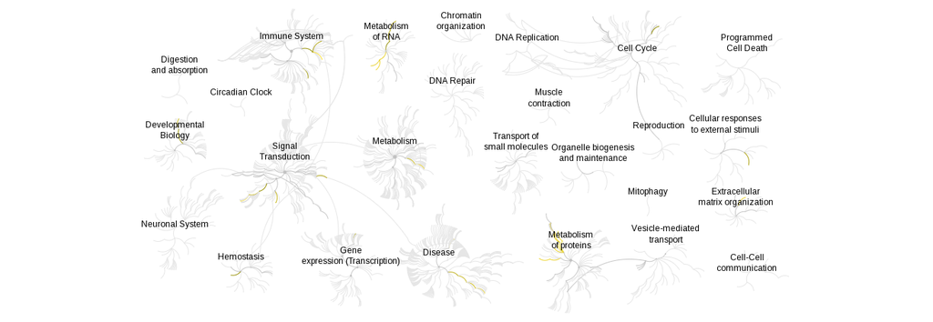

Figure.10 Pathway enriched by simple bootstrap and tabu-TAN

Table.4 Pathways enriched with tabu-TAN

| Pathway name | Entities FDR | Entities pValue |
| --- | --- | --- |
| Interleukin-4 and 13 signaling | 0.0128596 | 0.0000718 |
| Chemokine receptors bind chemokines | 0.0506245 | 0.0005688 |
| Peptide chain elongation | 0.0795339 | 0.0044351 |
| Nonsense Mediated Decay (NMD) independent of the Exon Junction Complex (EJC) | 0.0795339 | 0.0046877 |
| Eukaryotic Translation Elongation | 0.0795339 | 0.0050826 |
| ATF4 activates genes | 0.0795339 | 0.0051886 |
| Formation of a pool of free 40S subunits | 0.0795339 | 0.0053568 |
| Eukaryotic Translation Termination | 0.0795339 | 0.0056397 |
| Activation of Matrix Metalloproteinases | 0.0795339 | 0.0061680 |
| Viral mRNA Translation | 0.0795339 | 0.0063858 |
| Selenocysteine synthesis | 0.0795339 | 0.0068604 |
| L13a-mediated translational silencing of Ceruloplasmin expression | 0.0795339 | 0.0071883 |
| PERK regulates gene expression | 0.0795339 | 0.0072249 |
| SRP-dependent cotranslational protein targeting to membrane | 0.0795339 | 0.0076972 |
| GTP hydrolysis and joining of the 60S ribosomal subunit | 0.0795339 | 0.0078715 |
| Nonsense-Mediated Decay (NMD) | 0.0795339 | 0.0082271 |
| Nonsense Mediated Decay (NMD) enhanced by the Exon Junction Complex (EJC) | 0.0795339 | 0.0082271 |
| Eukaryotic Translation Initiation | 0.0795339 | 0.0095455 |
| Cap-dependent Translation Initiation | 0.0795339 | 0.0095455 |
| TCF7L2 mutants don’t bind CTBP | 0.0795339 | 0.0099417 |

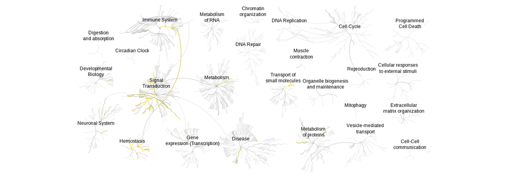

Table.5 Pathways enriched with pathway-TAN

| Pathway name | Entities FDR | Entities pValue |
| --- | --- | --- |
| Aquaporin-mediated transport | 0.0076293 | 0.0000175 |
| Platelet activation, signaling and aggregation | 0.0241779 | 0.0001644 |
| Peptide ligand-binding receptors | 0.0241779 | 0.0001667 |
| Transport of glycerol from adipocytes to the liver by Aquaporins | 0.0270360 | 0.0002752 |
| Glucagon signaling in metabolic regulation | 0.0270360 | 0.0003108 |
| Chemokine receptors bind chemokines | 0.0402486 | 0.0006140 |
| Glucagon-like Peptide-1 (GLP1) regulates insulin secretion | 0.0402486 | 0.0006627 |
| Vasopressin regulates renal water homeostasis via Aquaporins | 0.0402486 | 0.0007684 |
| GPCR ligand binding | 0.0402486 | 0.0008385 |
| GRB7 events in ERBB2 signaling | 0.0424566 | 0.0010839 |
| ADP signalling through P2Y purinoceptor 12 | 0.0424566 | 0.0010886 |
| G alpha (i) signalling events | 0.0454515 | 0.0012625 |
| Signaling by Interleukins | 0.0492229 | 0.0014916 |
| Activation of kainate receptors upon glutamate binding | 0.0806343 | 0.0026011 |
| Thrombin signalling through proteinase activated receptors (PARs) | 0.0818174 | 0.0028213 |
| Signal amplification | 0.0839378 | 0.0032953 |
| Formyl peptide receptors bind formyl peptides and many other ligands | 0.0839378 | 0.0035504 |
| RUNX1 regulates genes involved in megakaryocyte differentiation and platelet function | 0.0839378 | 0.0035739 |
| RA biosynthesis pathway | 0.0839378 | 0.0038154 |
| GP1b-IX-V activation signalling | 0.0876540 | 0.0042036 |
| Hemostasis | 0.0876540 | 0.0043827 |
| Class A/1 (Rhodopsin-like receptors) | 0.0892587 | 0.0046978 |
| Interleukin-10 signaling | 0.0981631 | 0.0054535 |
| Formation of Fibrin Clot (Clotting Cascade) | 0.1019586 | 0.0056644 |
| Cytokine Signaling in Immune system | 0.1069345 | 0.0062903 |
| Interleukin-4 and 13 signaling | 0.1091966 | 0.0070130 |
| Downregulation of ERBB2:ERBB3 signaling | 0.1091966 | 0.0073210 |
| Platelet Adhesion to exposed collagen | 0.1091966 | 0.0073210 |
| Class B/2 (Secretin family receptors) | 0.1091966 | 0.0081796 |
| Signaling by GPCR | 0.1091966 | 0.0082374 |
| Platelet Aggregation (Plug Formation) | 0.1091966 | 0.0083997 |
| G beta:gamma signalling through PI3Kgamma | 0.1091966 | 0.0083997 |
| ERBB2 Activates PTK6 Signaling | 0.1100537 | 0.0091711 |
| Opioid Signalling | 0.1118288 | 0.0093579 |
| Regulation of insulin secretion | 0.1118288 | 0.0096688 |

## 3.5 Bonus: **Play** with the net!

A Bayesian Network by `tabu-boot` will be normally similar to this.

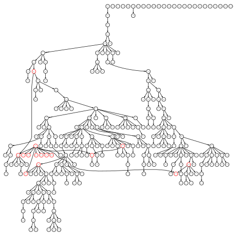

Figure.9 Static BN network, red nodes are the Markov blanket of ‘label’ and the ‘label’ node itself

Here is an interactive version of the same graph. You may zoom, drag the graph. Tooltips for each nodes gives the log fold change for this gene between AMI and control samples.

[interactive chart not shown]

# 4 Conclusion

The work presents a trial to integrate biological pathway data into feature learning process. The marriage between pathway network and causal Bayesian network might give more interpretable feature subsets, which may lead to better generalizablity. However it is also noted that there must be some more elegant mathematics formulation behind, which might involves a pathway-related loss function or regularization techniques.

# 5 Acknowledgement

Many thanks to Dr.Gil Alterovitz, Dr.Lin and Haipeng. It feels great to get a taste of machine learning with R. I will continue improve my knowledge for this area, to see if there can be some neat mathematics way to make a model with high intepretability while keeping its accuracy.

# Reference

Gentleman, R., V. Carey, W. Huber, and F. Hahne. 2017. *Genefilter: Genefilter: Methods for Filtering Genes from High-Throughput Experiments*.

Gevaert, O., F. D. Smet, D. Timmerman, Y. Moreau, and B. D. Moor. 2006. “Predicting the Prognosis of Breast Cancer by Integrating Clinical and Microarray Data with Bayesian Networks.” *Bioinformatics* 22 (14). Oxford University Press (OUP): e184–e190. doi:10.1093/bioinformatics/btl230.

Jed Wing, Max Kuhn. Contributions from, Steve Weston, Andre Williams, Chris Keefer, Allan Engelhardt, Tony Cooper, Zachary Mayer, et al. 2017. *Caret: Classification and Regression Training*. https://CRAN.R-project.org/package=caret.

Korkor, Melvin T., Fan Bo Meng, Shen Yang Xing, Mu Chun Zhang, Jin Rui Guo, Xiao Xue Zhu, and Ping Yang. 2011. “Microarray Analysis of Differential Gene Expression Profile in Peripheral Blood Cells of Patients with Human Essential Hypertension.” *International Journal of Medical Sciences* 8 (2). Ivyspring International Publisher: 168–79. doi:10.7150/ijms.8.168.

Nagarajan, Radhakrishnan, and Marco Scutari. 2013. *Bayesian Networks in R with Applications in Systems Biology*. New York: Springer. doi:10.1007/978-1-4614-6446-4.

Reimand, Juri, Raivo Kolde, and Tambet Arak. 2016. *GProfileR: Interface to the ’G:Profiler’ Toolkit*. https://CRAN.R-project.org/package=gProfileR.

Scutari, Marco. 2010. “Learning Bayesian Networks with the bnlearn R Package.” *Journal of Statistical Software* 35 (3): 1–22. doi:10.18637/jss.v035.i03.

Suresh, Rahul, Xing Li, Anca Chiriac, Kashish Goel, Andre Terzic, Carmen Perez-Terzic, and Timothy J. Nelson. 2014. “Transcriptome from Circulating Cells Suggests Dysregulated Pathways Associated with Long-Term Recurrent Events Following First-Time Myocardial Infarction.” *Journal of Molecular and Cellular Cardiology* 74 (September). Elsevier BV: 13–21. doi:10.1016/j.yjmcc.2014.04.017.

Tarca, Adi Laurentiu, Purvesh Kathri, and Sorin Draghici. 2013. *SPIA: Signaling Pathway Impact Analysis (Spia) Using Combined Evidence of Pathway over-Representation and Unusual Signaling Perturbations*. http://bioinformatics.oxfordjournals.org/cgi/reprint/btn577v1.

White, Harvey D, and Derek P Chew. 2008. “Acute Myocardial Infarction.” *The Lancet* 372 (9638). Elsevier BV: 570–84. doi:10.1016/s0140-6736(08)61237-4.

Wu, Jean, and Rafael Irizarry with contributions from James MacDonald Jeff Gentry. 2017. *Gcrma: Background Adjustment Using Sequence Information*.

Yu, Guangchuang, and Qing-Yu He. 2016. “ReactomePA: An R/Bioconductor Package for Reactome Pathway Analysis and Visualization.” *Molecular BioSystems* 12 (12): 477–79. doi:10.1039/C5MB00663E.